# {data.table}

Importer, formater et manipuler vos données: {data.table} vs {tidyverse}

R

data.table

tidyverse

Author

Pauline Lasserre-Zuber

Published

August 24, 2023

[figure not shown]

# Introduction

Pour des tables de données de taille petite et moyenne (inférieure à 1 Go ou moins d’un million d’observations), il est recommandé d’utiliser le package `dplyr`. Pour des tables de données de grande taille (plus de 1 Go ou plus d’un million d’observations), il est recommandé d’utiliser le package `data.table`.

Un des atouts fondamentaux de `data.table` est sa syntaxe compacte qui lui vaut sa rapidité : `data.table` ne manipule que les colonnes mentionnées dans l’opérateur `[…]`, ce qui réduit le temps de traitement des données.

La forme générale de l’opérateur `[…]` est la suivante :

```r
DT[i, j, by]
```

On part du data.table **DT**, on sélectionne certaines lignes avec **i**, puis on calcule **j** pour chaque groupe défini par **by**. Si on fait un parallèle avec SQL, i correspond au WHERE, j au SELECT et by au GROUP BY. La fonction `[…]` présente deux grands avantages: pas de préfixe DT$ pour se référer aux variables à l’intérieur de […] et sa concision.

Les fonctions `setDT()` et `as.data.table()` convertissent un data.frame en data.table

Les data.tables sont simplement des data.frames particuliers, donc on peut normalement leur appliquer toutes les méthodes valables pour les data.frames. En particulier, on peut utiliser avec data.table toutes les fonctions des packages habituellement associés à dplyr : stringr pour le maniement de chaînes de caractères, etc.

Sommaire :

**1. IMPORT DE TABLES FORMAT LONG: readr vs fread** : setup, import table 1, import table 2, sélection des données à importer, presentation des données

**2. CALCULS SUR LES COLONNES** : calculs par groupe selon critères, enchainer les calculs

**3. CREER UNE NOUVELLE COLONNE SELON CRITERES**

**4. SELECTIONNER DES COLONNES**: tydiverse, data.table

**5. JOINDRE DES TABLES**: Rbase, tydiverse, data.table avec ou sans index

**6. EXPORTATION DE TABLE**: Rbase, tydiverse, data.table

**7. IMPORT DE TABLE FORMAT LARGE**: tydiverse, data.table

**8. FORMATAGE DES DONNEES**: tydiverse, data.table

# 1. Importer des tables au format long : `readr` vs `fread`

## Setup

```r
# Chargement des packages
library(readr)
library(dplyr)
library(stringr)

library(data.table)
```

Télécharger les fichiers suivants (en cliquant sur l’icône **Download**) et sauvegardez-les dans votre répertoire de travail :

- [Fichier 1](https://forgemia.inra.fr/ateliers_codons/data.table/-/blob/main/ISBPS_REFSEQV2_vs_RENAN_PSEUDOV2_filtered.bam_summary.tsv)
- [Fichier 2](https://forgemia.inra.fr/ateliers_codons/data.table/-/blob/main/Tae.Chinese_Spring.refSeqv2.1.ISBPs_fasta.txt)

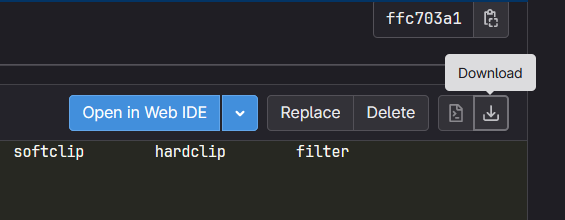

## Import table 1

```r
# package readr de la suite tidyverse
start.time <- Sys.time()
d <- read_tsv("ISBPS_REFSEQV2_vs_RENAN_PSEUDOV2_filtered.bam_summary.tsv", col_names=T)
time.tidy <- Sys.time() - start.time
```

```r
#package data.table
##info systeme:
names(s <- Sys.getenv())
Sys.getenv("NUMBER_OF_PROCESSORS")
Sys.getenv("PROCESSOR_LEVEL")
Sys.getenv("OMP_THREAD_LIMIT")
Sys.setenv("OMP_THREAD_LIMIT"=4)
Sys.getenv("OMP_THREAD_LIMIT")


##nThread=1
setDTthreads(threads=1, restore_after_fork=TRUE)
getDTthreads(verbose = getOption("datatable.verbose"))

start.time <- Sys.time()
dt <- fread("ISBPS_REFSEQV2_vs_RENAN_PSEUDOV2_filtered.bam_summary.tsv",
         nThread=1, sep="\t", header=TRUE, dec=".", encoding = "UTF-8", showProgress=TRUE)
time.dt1 <- Sys.time() - start.time
time.dt1
time.tidy

##nThread=4
setDTthreads(threads=6, restore_after_fork=TRUE)
getDTthreads(verbose = getOption("datatable.verbose"))

start.time <- Sys.time()
dt <- fread("ISBPS_REFSEQV2_vs_RENAN_PSEUDOV2_filtered.bam_summary.tsv",
         nThread=4, sep="\t", header=TRUE, dec=".", encoding = "UTF-8", showProgress=TRUE)
time.dt4 <- Sys.time() - start.time
time.dt4
time.tidy

#definition d'un deuxieme seprarteur (sep2) possible !!! :))
#NB: option stringsAsFactors = TRUE peut ralentir sensiblement l’importation des donnees
```

## Import table 2

```r
#package readr de la suite tidyverse
start.time <- Sys.time()
fa <- read_tsv("Tae.Chinese_Spring.refSeqv2.1.ISBPs_fasta.txt", col_names=F)
time.tidy <- Sys.time() - start.time

colnames(fa) <- c("read_id","seq")

#package data.table  ---> nThread
start.time <- Sys.time()
fadt <- fread("Tae.Chinese_Spring.refSeqv2.1.ISBPs_fasta.txt",
           nThread=4, sep="\t", colClasses=c("character", "character"), header=FALSE,
           encoding = "UTF-8", showProgress=TRUE)
time.dt4 <- Sys.time() - start.time
time.dt4
time.tidy
```

## Sélection des données à importer

```r
# #package readr de la suite tidyverse
start.time <- Sys.time()
d <- read_tsv("ISBPS_REFSEQV2_vs_RENAN_PSEUDOV2_filtered.bam_summary.tsv", col_names=T,
           col_select = -"query_length")
time.tidy <- Sys.time() - start.time


#pour selectionner des colonnes à importer: option "col_select" avec ou sans -
#pour importer une portion de table: option "skip" et "n_max


#package data.table
start.time <- Sys.time()
dt <- fread("ISBPS_REFSEQV2_vs_RENAN_PSEUDOV2_filtered.bam_summary.tsv",
         nThread=4, sep="\t", header=TRUE, dec=".", encoding = "UTF-8", showProgress=TRUE,
         drop="query_length")
time.dt4 <- Sys.time() - start.time
time.dt4
time.tidy

#pour selectionner des colonnes à importer: option "clo_select" avec ou sans -
#pour importer une portion de table: option "skip" + "nrows"
```

## Presentation des données {#presentation}

```r
#suite tidyverse
d
fa

df <- data.frame(d)
fadf <- data.frame(fa)

#package data.table
dt
fadt
colnames(fadt) <- c("read_id","seq")

options("datatable.print.keys" = TRUE, "datatable.print.class" = TRUE)
dt
```

# 2. Calculs sur les colonnes

## Calculs par groupe selon critères

```r
# R base
start.time <- Sys.time()
head(df)
aggregate(df[df[["alignemnt_length"]]==150, "mapq"],
          by=list(df[df[["alignemnt_length"]]==150, "missmatches"]),
          FUN=mean)
Sys.time() - start.time

#suite tidyverse
start.time <- Sys.time()
print(d %>%
  dplyr::filter(alignemnt_length==150)%>%
  dplyr::group_by(missmatches)%>%
  dplyr::summarise(mean(mapq)),
  n=100)
Sys.time() - start.time


#package data.table
start.time <- Sys.time()
dt[alignemnt_length==150, mean(mapq), by = missmatches]
Sys.time() - start.time
```

## Enchainer les calculs {#arrange}

Dplyr utilise l’opérateur pipe %>%.

Avec data.table, il suffit d’accoler les opérateurs []: dt[opération 1][opération 2][opération 3][…]

```r
#suite tidyverse
print(d %>%
        dplyr::filter(alignemnt_length==150) %>%
        dplyr::group_by(missmatches) %>%
        dplyr::summarise(mean(mapq))%>%
        arrange(`mean(mapq)`),
      n=100)

#package data.table
dt[alignemnt_length==150, mean(mapq), by = missmatches][order(missmatches)]
```

# 3. Créer une nouvelle colonnes selon critères

```r
#suite tidyverse
##dim ligne --NON-- constante, dim colonne +1 : on cree la colonne nomee "keep"
d_filt=d %>%
  filter(alignemnt_length==150 & mapq==60)%>%
  mutate(keep="OK")
d_filt

##dim ligne constante, dim colonne +1 : on cree la colonne nomee "keep"
start.time <- Sys.time()
d=d %>%
  mutate(keep=if_else(alignemnt_length==150 & mapq==60,"OK","NA"))
Sys.time() - start.time

d
#NB: assignation necessaire


#package data.table
##utilise beaucoup moins de memoire vive
##la fonction := s’appelle “assignation par reference”, elle peut prendre des arguments entre parentheses`:=`()

##dim ligne --NON-- constante, dim colonne +1
dt_filt=dt[alignemnt_length==150 & mapq==60][, keep:= "OK"]
dt_filt

##dim ligne constante, dim colonne +1
start.time <- Sys.time()
dt[alignemnt_length==150 & mapq==60, keep:= "OK"]
#NB: pas d'assignation, table modifiee par reference
Sys.time() - start.time

dt[, keep:= "OK"][alignemnt_length!=150 | mapq!=60, keep:= NA]
```

# 4. Sélectionner des colonnes

## tidyverse

```r
#suite tidyverse
d%>%select(read_id, missmatches, mapq)

#package data.table
dt[, .(read_id, missmatches, mapq)]   #NB: .() est un alias pour "list()"

dt[, .SD, .SDcols=c("read_id", "missmatches", "mapq")] #ecriture a combiner avec lapply
#SD pour Subset of Data: les colonnes listees seront aliasees par .SD avec la dimension .SDcols
#et par defaut, toutes les colonnes sont traitees
```

## data.table {#data.table1}

```r
#
```

# 5. Joindre des tables

## Rbase

```r
 # R base
start.time <- Sys.time()
#df_join=base::merge(df,fadf, by="read_id", all.x=TRUE)
Sys.time() - start.time
#####Time difference of 1.373174 mins
```

## tydiverse {#tidyverse2}

```r
#suite tidyverse
start.time <- Sys.time()
d_join=d%>%left_join(fa)   #NB: une seule var key commune, nul besoin de preciser la var de jointure
#sinon: d_join=d%>%left_join(y=fa, by="read_id")
Sys.time() - start.time
```

## data.table avec ou sans index {#data.table2}

```r
#package data.table
##avec merge, meme ecriture qu'avec la fonction de R base

start.time = Sys.time()
dt_join=merge(dt,fadt, by="read_id", all.x=T)
time.dt_sansindex = Sys.time() - start.time

start.time = Sys.time()
dt_join=dt[fadt, on="read_id", nomatch=NULL]
Sys.time() - start.time

##indexation de tables: accelere les combinaisons de donnees
setkey(dt, read_id)
setkey(fadt, read_id)

start.time = Sys.time()
dt_join=merge(dt,fadt, by="read_id", all.x=T)
time.dt_avecindex = Sys.time() - start.time
time.dt_sansindex
time.dt_avecindex

key(dt)
setkey(dt, NULL)
key(dt)
```

# 6. Exporter des tables

## Rbase

```r
#R base
start.time <- Sys.time()
#write.table(df_join, "ISBP_REFSEQV2_vs_RENAN_with_FASTA.TAB", col.names=T)
Sys.time() - start.time
#Time difference of 1.977623 mins
```

## tydiverse {#tidyverse3}

```r
#suite tidyverse package readr
start.time <- Sys.time()
write_tsv(d_join, "ISBP_REFSEQV2_vs_RENAN_with_FASTA.TAB", col_names=T)
Sys.time() - start.time  # ~20 à 30sec
```

## data.table {#data.table3}

```r
#package data.table
start.time <- Sys.time()
fwrite(dt_join, "ISBP_REFSEQV2_vs_RENAN_with_FASTA.TAB", col.names=T)
Sys.time() - start.time  # moins de 2 secondes
```

# 7. Importer des tables au format large

## tydiverse

```r
# TRANSPOSITION
mat_join=as.matrix(dt_join)
dim(mat_join)
head(mat_join, n=1)
colnames(mat_join)

tmat_join=as.matrix(t(mat_join))
dim(tmat_join)
head(tmat_join[,c(1,2,3,4,5)], n=9)
tmat_join=data.table(tmat_join)

fwrite(tmat_join, "ISBP_REFSEQV2_vs_RENAN_with_FASTA_transposed_dt.TAB", sep="\t", col.names=F)

#package readr de la suite tidyverse
start.time <- Sys.time()
#d_trans=read_tsv("ISBP_REFSEQV2_vs_RENAN_with_FASTA_transposed_dt.TAB", col_names=F)
time.tidy <- Sys.time() - start.time ## tres tres long
```

## data.table {#data.table4}

```r
#package data.table
start.time <- Sys.time()
dt_trans=fread("ISBP_REFSEQV2_vs_RENAN_with_FASTA_transposed_dt.TAB",
         nThread=4, sep="\t", header=FALSE, dec=".", encoding = "UTF-8", showProgress=TRUE)
time.dt <- Sys.time() - start.time
time.dt # ~16 secondes
time.tidy
```

# 8. Formater des données

## tydiverse

```r
# mutate sur une colonne avec tidyverse
start.time <- Sys.time()
d_joinU=d_join %>% head(5)%>%mutate(seq=str_replace_all(seq,"T","U"))
time.tidy <- Sys.time() - start.time

### mutate(across) sur toutes les colonnes
tmat_d_join=tibble(tmat_join[,1:100000])

start.time <- Sys.time()
tmat_d_joinU=tmat_d_join %>% mutate(across(everything(), ~gsub("T","U",.)))
time.tidy <- Sys.time() - start.time
time.tidy

head(tmat_d_joinU[,c(1,2,3,4,5)], n=9)
```

## data.table

```r
# str_replace sur une colonne
start.time <- Sys.time()
dt_joinU=dt_join[1:5,][,seq:=str_replace_all(seq,"T","U")]
time.dt <- Sys.time() - start.time
time.dt
time.tidy

### lapply .SD .SDcols sur 5 colonnes
cols=c("V1","V2","V3","V4","V5")
tmat_dt_joinU=tmat_dt_join[,(cols):=lapply(.SD, function(x) gsub("T","U",as.character(x))), .SDcols=cols]
head(tmat_dt_joinU[,c(1,2,3,4,5)], n=9)

### lapply .SD .SDcols sur toutes les colonnes
cols=c("V1","V2","V3","V4","V5")
start.time <- Sys.time()
tmat_dt_joinU=lapply(tmat_dt_join, function(x) gsub("T","U",as.character(x)) )
time.dt <- Sys.time() - start.time
time.dt

head(tmat_dt_joinU[,c(1,2,3,4,5)], n=9)
```

*Références [UtilitR](https://www.book.utilitr.org/datatable.html)*